# Run the cell below to generate the road map (do not modify it)

#### Question 6.2

Calculate the covariance matrix $\sum$ and the means $\mu$ of factors' returns then generate a random vector of factors return that follows a multivariate normal distribution $\sim N(\mu, \sum)$

HINT: Function `np.cov` can help calculating covariance matrix. Function `np.random.multivariate_normal(<mean>, <cov>)` is often used for generating samples.

```
factorCov = ...
factorMeans = [sum(...)/len(...) for ... in ...]
sample = ...
print(factorCov)
print(factorMeans)
print(sample)
```

```python
factorCov = np.cov(factorsReturns)
factorMeans = [sum(factorReturns)/len(factorReturns) for factorReturns in factorsReturns]
sample = np.random.multivariate_normal(factorMeans, factorCov)
print(factorCov)
print(factorMeans)
print(sample)
```

```
[[  2.03712313e+01   2.70383097e-01   6.74442782e+01   1.63697774e+02]
 [  2.70383097e-01   2.42014227e-02   2.58869879e+00   6.36011613e+00]
 [  6.74442782e+01   2.58869879e+00   1.29672509e+03   2.71521187e+03]
 [  1.63697774e+02   6.36011613e+00   2.71521187e+03   6.70934736e+03]]
[0.35908880308880364, 0.0019722007722007863, 6.970339789189207, 18.737721800000003]
[ -2.57019519   0.1547435  -28.38245607 -91.04855327]
```

Let's plot one the same figure the normal estimate and the true distributions of each different factors. It will give an idea of how well the normal distribution fit the factors.

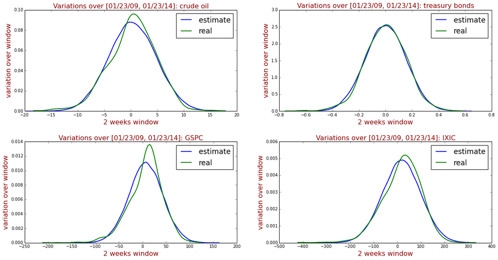

```python
# Compare our normal estimates and the real distributions
factorsNames = ["crude oil", "treasury bonds", "GSPC", "IXIC"]

numSamples = 50000 # to plot normal distributions
f, axarr = plt.subplots(2, 2)
f.set_figwidth(20)
f.set_figheight(10)
for (idx, factorReturn) in enumerate(factorsReturns):
    i, j = divmod(idx, 2)
    ax = axarr[i, j]
    normalEstimates = [np.random.multivariate_normal(factorMeans, factorCov)[idx] for k in range(numSamples)]
    domainEstimates, densityEstimates = plotDistribution(normalEstimates, plot=False)
    domainFactor, densityFactor = plotDistribution(factorReturn, plot=False)
    ax.plot(domainEstimates, densityEstimates, lw=2)
    ax.plot(domainFactor, densityFactor, lw=2)
    ax.set_title("Variations over [{}, {}]: {}".format(start.strftime("%D"), end.strftime("%D"), factorsNames[idx])
                , fontdict=font)
    ax.set_xlabel("2 weeks window", fontdict=font)
    ax.set_ylabel("variation over window", fontdict=font)
    ax.legend(["estimate", "real"], fontsize="xx-large")
f.subplots_adjust(hspace=0.3)
```

The two firts factors seem to be well fitted to the model (crude oil and treasury bonds). The two others (GSPC and IXIC) are more flawed. This tells us that if our goal is to fit well the distibution with a probability model, then we should consider using different types of probability distributions for each factor.

### Step 3&4: Generating samples, running simulation and calculating the VaR

We define some functions that helps us calculating VaR 5%. You will see that the functions below are pretty complicated! This is why we provide a solution for you: however, study them well!!

The basic idea of calculating VaR 5% is that we need to find a value such that only 5% of the losses are bigger than it. That means the 5th percentile of the losses should be VaR 5%.

VaR can sometimes be problematic though, since it does give any information on the extent of the losses which can exceed the VaR estimate. CVar is an extension of VaR that is introduced to deal with this problem. Indeed, CVaR measures the expected value of the loss in those cases where VaR estimate has been exceeded.

```python
import time
def fivePercentVaR(trials):
    numTrials = trials.count()
    topLosses = trials.takeOrdered(max(round(numTrials/20.0), 1))
    return topLosses[-1]

# an extension of VaR
def fivePercentCVaR(trials):
    numTrials = trials.count()
    topLosses = trials.takeOrdered(max(round(numTrials/20.0), 1))
    return sum(topLosses)/len(topLosses)

def bootstrappedConfidenceInterval(
      trials, computeStatisticFunction,
      numResamples, pValue):
    stats = []
    t = time.time()
    for i in range(0, numResamples):
        # This is just to know when it'll be finished when it runs on a laptop.
        update(i,numResamples,t)

        resample = trials.sample(True, 1.0)
        stats.append(computeStatisticFunction(resample))

    sorted(stats)
    lowerIndex = int(numResamples * pValue / 2 - 1)
    upperIndex = int(np.ceil(numResamples * (1 - pValue / 2)))
    return (stats[lowerIndex], stats[upperIndex])
```

Next, we will run the Monte Carlo simulation 10,000 times, in parallel using Spark. Since your cluster has 12 cores (two Spark worker nodes, each with 6 cores), we can set `parallelism = 12` to dispatch simulation on these cores, across the two machines (remember, those are not really "physical machines", they are Docker containers running in our infrastructure).

[figure not shown]

### Question 7

Complete the code below to define the simulation process and calculate VaR 5%.

```
# RUN SILMULATION
def simulateTrialReturns(numTrials, factorMeans, factorCov, weights):
    trialReturns = []
    for i in range(0, numTrials):
        # generate sample of factors' returns
        trialFactorReturns = ...

        # featurize the factors' returns
        trialFeatures = ...

        # insert weight for intercept term
        trialFeatures.insert(0,1)

        trialTotalReturn = 0

        # calculate the return of each instrument
        # then calulate the total of return for this trial features
        trialTotalReturn = ...

        trialReturns.append(trialTotalReturn)
    return trialReturns



parallelism = 12
numTrials = 10000
trial_indexes = list(range(0, parallelism))
seedRDD = sc.parallelize(trial_indexes, parallelism)
bFactorWeights = sc.broadcast(weights)

trials = seedRDD.flatMap(lambda idx: \
                simulateTrialReturns(
                    max(int(numTrials/parallelism), 1),
                    ..., ...,
                    ...
                ))
trials.cache()

valueAtRisk = fivePercentVaR(...)
conditionalValueAtRisk = fivePercentCVaR(...)

print "Value at Risk(VaR) 5%:", valueAtRisk
print "Conditional Value at Risk(CVaR) 5%:", conditionalValueAtRisk
```

```python
# RUN SILMULATION
def simulateTrialReturns(numTrials, factorMeans, factorCov, weights):
    trialReturns = []
    for i in range(0, numTrials):
        # generate sample of factors' returns
        trialFactorReturns = np.random.multivariate_normal(factorMeans, factorCov)

        # featurize the factors' returns
        trialFeatures = featurize(trialFactorReturns)

        # insert weight for intercept term
        trialFeatures.insert(0,1)

        trialTotalReturn = 0

        # calculate the return of each instrument
        # then calulate the total of return for this trial features
        for stockWeights in weights:
            instrumentReturn = sum([stockWeights[i] * trialFeatures[i] for i in range(len(trialFeatures))])
            trialTotalReturn += instrumentReturn

        trialReturns.append(trialTotalReturn)
    return trialReturns


parallelism = 2
numTrials = 10000
trial_indexes = list(range(0, parallelism))
seedRDD = sc.parallelize(trial_indexes, parallelism)
bFactorWeights = sc.broadcast(weights)

trials = seedRDD.flatMap(lambda idx: \
                simulateTrialReturns(
                    max(int(numTrials/parallelism), 1),
                    factorMeans, factorCov,
                    bFactorWeights.value
                ))
trials.cache()

valueAtRisk = fivePercentVaR(trials)
conditionalValueAtRisk = fivePercentCVaR(trials)

print ("Value at Risk(VaR) 5%:", valueAtRisk)
print ("Conditional Value at Risk(CVaR) 5%:", conditionalValueAtRisk)
```

```
Value at Risk(VaR) 5%: -34.8709658077
Conditional Value at Risk(CVaR) 5%: -42.3444901359
```

We'll see how is the distribution of random returns:

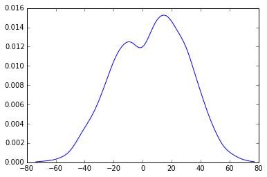

```python
plotDistribution(trials.collect())
```

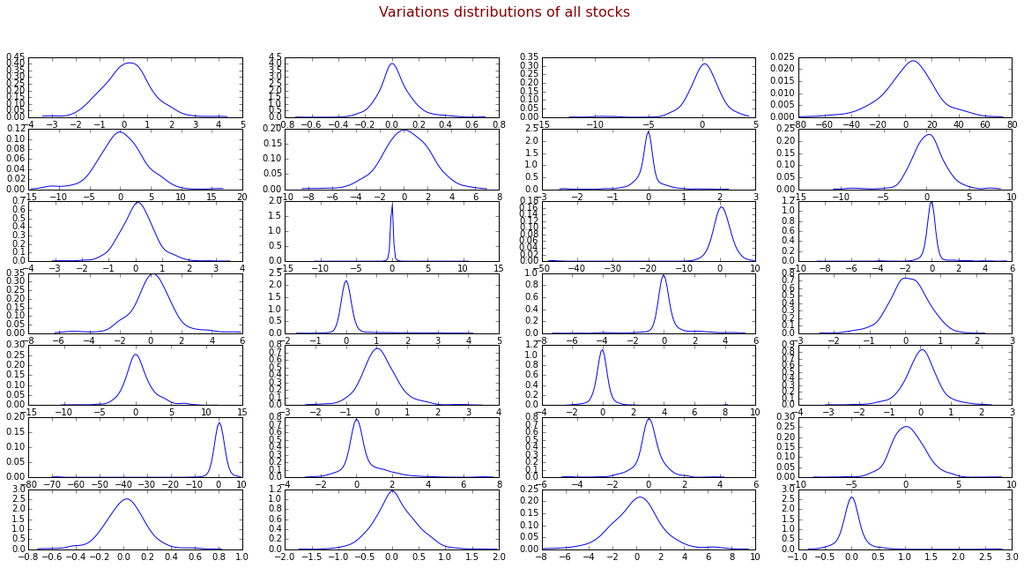

```python
nCols = 4
nRows = int(np.ceil(len(stocksReturns)/nCols))
f , axarr = plt.subplots(nRows, nCols)
f.suptitle("Variations distributions of all stocks", fontdict=font)
f.set_figwidth(20)
f.set_figheight(10)
for idx, stockReturn in enumerate(stocksReturns):
    i, j = divmod(idx, nCols)
    ax = axarr[i, j]
    domain, density = plotDistribution(stockReturn, plot=False)
    ax.plot(domain, density)
```

The value of VaR depends on how many invested stocks and the chosen distribution of random variables. Assume that we get VaR 5% = -2.66, that means that there is a 0.05 probability that the portfolio will fall in value by more than \$2.66 over a two weeks period if there is no trading. In other words, the loses are less than \$2.66 over two weeks period with 95% confidence level. When a loss over two weeks is more than \$2.66, we call it **failure** (or **exception**). Informally, because of 5% probability, we expect that there are only $0.05*W$ failures out of total $W$ windows.

### Step 5: Evaluating the results using backtesting method

In general, the error in a Monte Carlo simulation should be proportional to 1/sqrt(n), where n is the number of trials. This means, for example, that quadrupling the number of trials should approximately cut the error in half. A good way to check the quality of a result is backtesting on historical data. Backtesting is a statistical procedure where actual losses are compared to the estimated VaR. For instance, if the confidence level used to calculate VaR is 95% (or VaR 5%), we expect only 5 failures over 100 two-week time windows.

The most common test of a VaR model is counting the number of VaR failures, i.e, in how many windows, the losses exceed VaR estimate. If the number of exceptions is less than selected confidence level would indicate, the VaR model overestimates the risk. On the contrary, if there are too many exceptions, the risk is underestimated. However, it's very hard to observe the amount of failures suggested by the confidence level exactly. Therefore, people try to study whether the number of failures is reasonable or not, or will the model be accepted or rejected.

One common test is Kupiec's proportion-of-failures (POF) test. This test considers how the portfolio performed at many historical time intervals and counts the number of times that the losses exceeded the VaR. The null hypothesis is that the VaR is reasonable, and a sufficiently extreme test statistic means that the VaR estimate does not accurately describe the data. The test statistic is computed as:

$$ -2ln\Bigg(\frac{(1-p)^{T-x}p^x}{(1-\frac{x}{T})^{T-x}(\frac{x}{T})^x}\Bigg) $$

where:

$p$ is the quantile-of-loss of the VaR calculation (e.g, in VaR 5%, p=0.05),

$x$ (the number of failures) is the number of historical intervals over which the losses exceeded the VaR

$T$ is the total number of historical intervals considered

Or we can expand out the log for better numerical stability:

$$ \begin{equation} -2\Big((T-x)ln(1-p)+x*ln(p)-(T-x)ln(1-\frac{x}{T})-x*ln(\frac{x}{T})\Big) \end{equation} $$

If we assume the null hypothesis that the VaR is reasonable, then this test statistic is drawn from a chi-squared distribution with a single degree of freedom. By using Chi-squared distribution, we can find the `p-value` accompanying our test statistic value. If `p-value` exceeds the critical value of the Chi-squared distribution, we do have sufficient evidence to reject the null hypothesis that the model is reasonable. Or we can say, in that case, the model is considered as inaccurate.

[figure not shown]

### Question 8

#### Question 8.1

Write a function to calculate the number of failures, that is when the losses (in the original data) exceed the VaR.

HINT:

- First, we need to calculate the total loss in each 2-week time interval
- If the total loss of a time interval exceeds VaR, then we say that our VaR fails to estimate the risk in that time interval.
- Return the number of failures

NOTE: The loss is often has negative value, so, be careful when compare it to VaR.

```
from scipy import stats
import math

def countFailures(stocksReturns, valueAtRisk):
    failures = 0
    # iterate over time intervals
    for i in range(0, ...):
        # calculate the losses in each time interval
        loss = ...

        # if the loss exceeds VaR
        if ...:
            failures += 1
    return failures
```

```python
from scipy import stats
import math

def countFailures(stocksReturns, valueAtRisk):
    failures = 0
    # iterate over time intervals
    for i in range(0, len(stocksReturns[0])):
        # calculate the losses in each time interval
        loss = -sum([ stockReturn[i] for stockReturn in stocksReturns])

        # if the loss exceeds VaR
        if loss > -valueAtRisk:
            failures += 1
    return failures
```

#### Question 8.2

Write a function named `kupiecTestStatistic` to calculate the test statistic which was described in the above equation.

```
def kupiecTestStatistic(total, failures, confidenceLevel):
    failureRatio = .../...
    logNumer = ...
    logDenom = ...
    return -2 * (logNumer - logDenom)

# test the function
assert (round(kupiecTestStatistic(250, 36, 0.1), 2) == 4.80), "function kupiecTestStatistic runs incorrectly"
```

```python
def kupiecTestStatistic(total, failures, confidenceLevel):
    failureRatio = failures/total
    logNumer = (total - failures) * np.log(1-confidenceLevel) + failures * np.log(confidenceLevel)
    logDenom = (total - failures) * np.log(1-failureRatio) + failures * np.log(failureRatio)
    return -2 * (logNumer - logDenom)

# test the function
assert (round(kupiecTestStatistic(250, 36, 0.1), 2) == 4.80), "function kupiecTestStatistic runs incorrectly"
```

```
65 64.75
```

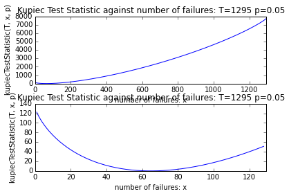

```python
# This piece of code shows the evidence that the minimum value of the KupiecTestStatistic
# is reached when the number of failures is equal to T*p, the function is very low around the min but vary a lot in the boundaries

p = 0.05
T = len(stocksReturns[0])
x = np.arange(0, T, 1)
y = list(map(lambda x: kupiecTestStatistic(T, x, p), x))
f, (ax1, ax2) = plt.subplots(2, 1)
ax1.set_xlabel("number of failures: x")
ax1.set_ylabel("kupiecTestStatistic(T, x, p)")
ax1.set_title("Kupiec Test Statistic against number of failures: T=" + str(T) + " p=" + str(p))
ax1.set_xlim(0,T)
ax1.plot(x, y)
ax2.set_xlabel("number of failures: x")
ax2.set_ylabel("kupiecTestStatistic(T, x, p)")
ax2.set_title("Kupiec Test Statistic against number of failures: T=" + str(T) + " p=" + str(p))
ax2.set_xlim(0, T*0.1)
ax2.plot(x[:int(T*0.1)], y[:int(T*0.1)])
f.subplots_adjust(hspace=0.3)
print(y.index(min(y[1:])), T*p)
```

Now we can find the p-value accompanying our test statistic value.

```python
def kupiecTestPValue(stocksReturns, valueAtRisk, confidenceLevel):
    failures = countFailures(stocksReturns, valueAtRisk)
    print("num failures:", failures)
    if failures == 0:
        # the model is very good
        return 1
    total = len(stocksReturns[0])
    print("failure percentage: ", failures*100/total, "%")
    testStatistic = kupiecTestStatistic(total, failures, confidenceLevel)
    print("testStatistic: ", testStatistic)
    return stats.chi2.sf(testStatistic, 1)
    # return 1 - stats.chi2.cdf(testStatistic, 1.0)
    # return stats.chisqprob(testStatistic, 1.0)

varConfidenceInterval = bootstrappedConfidenceInterval(trials, fivePercentVaR, 100, 0.05)
cvarConfidenceInterval = bootstrappedConfidenceInterval(trials, fivePercentCVaR, 100, .05)
print("Value at risk: ", valueAtRisk)
print("VaR confidence interval: " , varConfidenceInterval)
print("CVaR confidence interval: " , cvarConfidenceInterval)
print("Kupiec test p-value: " , kupiecTestPValue(stocksReturns, valueAtRisk, 0.05))
```

[output not shown]

[output not shown]

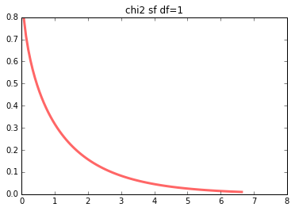

```python
# See the chi 2 survival function distribution (defined as 1 - chi2.cdf(x))

df = 1 # degree of freedom: 1
fig, ax = plt.subplots(1, 1)
x = np.linspace(0, stats.chi2.ppf(0.99, df), 100)
ax.plot(x, stats.chi2.sf(x, df), lw=3, alpha=0.6, color="red")
plt.title("chi2 sf df=" + str(df))
plt.ylim(0, 0.8)
plt.xlim(0, 8)
```

#### Question 8.3

Discuss the results you have obtained

[figure not shown]

### Question 9

Assume that we invest in more than 100 stocks. Use the same market factors as for the previous questions to estimate VaR by running MCS, then validate your result.

What is the main observation you have, once you answer this question? When you plan to invest in more instruments, how is your ability to predict the risk going to be affected?

```python
def wholeRun(numberOfFiles, factorReturns, factorMeans, factorCov,
             start = datetime(year=2009, month=1, day=23),
             end = datetime(year=2014, month=1, day=23),
             number_of_years = 5):

    # select path of all stock data files in "stock_folder"
    files = [join(stock_folder, f) for f in listdir(stock_folder) if isfile(join(stock_folder, f))]

    # assume that we invest only the first 35 stocks (for faster computation)
    files = files[:numberOfFiles]
    # read each line in each file, convert it into the format: (date, value)
    rawStocks = [process_stock_file(f) for f in files]

    # select only instruments which have more than 5 years of history
    # Note: the number of business days in a year is 260
    number_of_years = 5
    rawStocks = list(filter(lambda instrument: len(instrument)>=260*number_of_years , rawStocks))

    # For testing, print the first 5 entry of the first stock
    print(rawStocks[0][:5])

    # test our function
    trimmedStock0  = trimToRegion(rawStocks[0], start, end) # Changed stocks to rawStocks
    # the first 5 records of stock 0
    print(trimmedStock0[:5])
    # the last 5 records of stock 0
    print(trimmedStock0[-5:])

    assert (trimmedStock0[0][0] == start), "the first record must\
    contain the price in the first day of time interval"
    assert (trimmedStock0[-1][0] == end), "the last record must\
    contain the price in the last day of time interval"

    # trim into a specific time region
    # and fill up the missing values
    stocks = list(map(lambda stock: \
                fillInHistory(
                    trimToRegion(stock, start, end),
                start, end),
            rawStocks))

    # test our code
    print("the first 5 records of stock 0:", stocks[0][:5], "\n")
    print("the last 5 records of stock 0:", stocks[0][-5:], "\n")

    stocksReturns = list(map(twoWeekReturns, stocks))
    print("the first 5 returns of stock 0:", stocksReturns[0][:5])
    print("the last 5 returns of stock 0:", stocksReturns[0][-5:])

    # transpose factorsReturns
    factorMat = transpose(factorsReturns)

    # featurize each row of factorMat
    factorFeatures = list(map(featurize,factorMat))

    # OLS require parameter is a numpy array
    factor_columns = np.array(factorFeatures)

    #add a constant - the intercept term for each instrument i.
    factor_columns = sm.add_constant(factor_columns, prepend=True)

    # estimate weights
    weights = [estimateParams(stockReturns, factor_columns) for stockReturns in stocksReturns]

    print("number of weights:", len(weights))

    parallelism = 2
    numTrials = 10000
    trial_indexes = list(range(0, parallelism))
    seedRDD = sc.parallelize(trial_indexes, parallelism)
    bFactorWeights = sc.broadcast(weights)

    trials = seedRDD.flatMap(lambda idx: \
                    simulateTrialReturns(
                        max(int(numTrials/parallelism), 1),
                        factorMeans, factorCov,
                        bFactorWeights.value
                    ))
    trials.cache()

    valueAtRisk = fivePercentVaR(trials)
    conditionalValueAtRisk = fivePercentCVaR(trials)

    print ("Value at Risk(VaR) 5%:", valueAtRisk)
    print ("Conditional Value at Risk(CVaR) 5%:", conditionalValueAtRisk)

    varConfidenceInterval = bootstrappedConfidenceInterval(trials, fivePercentVaR, 100, 0.05)
    cvarConfidenceInterval = bootstrappedConfidenceInterval(trials, fivePercentCVaR, 100, .05)
    print("VaR confidence interval: " , varConfidenceInterval)
    print("CVaR confidence interval: " , cvarConfidenceInterval)
    print("Kupiec test p-value: " , kupiecTestPValue(stocksReturns, valueAtRisk, 0.05))
```

```python
wholeRun(120, factorsReturns, factorMeans, factorCov)
```

```
[(datetime.datetime(1990, 3, 26, 0, 0), 34.000027), (datetime.datetime(1990, 3, 27, 0, 0), 34.250016), (datetime.datetime(1990, 3, 28, 0, 0), 34.500001), (datetime.datetime(1990, 3, 29, 0, 0), 34.500001), (datetime.datetime(1990, 3, 30, 0, 0), 34.500001)]
[(datetime.datetime(2009, 1, 23, 0, 0), 2.68), (datetime.datetime(2009, 1, 26, 0, 0), 3.03), (datetime.datetime(2009, 1, 27, 0, 0), 2.83), (datetime.datetime(2009, 1, 28, 0, 0), 3.05), (datetime.datetime(2009, 1, 29, 0, 0), 3.43)]
[(datetime.datetime(2014, 1, 16, 0, 0), 21.49), (datetime.datetime(2014, 1, 17, 0, 0), 21.459999), (datetime.datetime(2014, 1, 21, 0, 0), 21.629999), (datetime.datetime(2014, 1, 22, 0, 0), 21.959999), (datetime.datetime(2014, 1, 23, 0, 0), 21.65)]
the first 5 records of stock 0: [(datetime.datetime(2009, 1, 23, 0, 0), 2.68), (datetime.datetime(2009, 1, 26, 0, 0), 3.03), (datetime.datetime(2009, 1, 27, 0, 0), 2.83), (datetime.datetime(2009, 1, 28, 0, 0), 3.05), (datetime.datetime(2009, 1, 29, 0, 0), 3.43)]

the last 5 records of stock 0: [(datetime.datetime(2014, 1, 16, 0, 0), 21.49), (datetime.datetime(2014, 1, 17, 0, 0), 21.459999), (datetime.datetime(2014, 1, 20, 0, 0), 21.459999), (datetime.datetime(2014, 1, 21, 0, 0), 21.629999), (datetime.datetime(2014, 1, 22, 0, 0), 21.959999)]

the first 5 returns of stock 0: [-1.1, -1.1899999999999997, 0.31999999999999984, -0.21999999999999975, -1.0500000000000003]
the last 5 returns of stock 0: [0.5799999999999983, 0.44999899999999826, 0.36999899999999997, 0.609999000000002, 0.8200000000000003]
number of weights: 101
Value at Risk(VaR) 5%: -58.7133800928
Conditional Value at Risk(CVaR) 5%: -75.9920189823
VaR confidence interval:  (-59.224729429507072, -59.753862040893772)
CVaR confidence interval:  (-77.002269758067555, -76.434156980439511)
num failures: 98
failure percentage:  7.5675675675675675 %
testStatistic:  15.6358762995
Kupiec test p-value:  7.67839015654e-05
```

[figure not shown]

### Question 10

In the previous questions, we used the normal distributions to sample the factors returns.

Try to study how results vary when selecting other probability distributions: our goal is to improve the result of our MCS.

Before going any further, I would like to adress an issue that bothered me a bit. We train our model with the data over 5 years, and then validate it with the same dataset. If it was a correct way of validating then we could run this piece of code to have a perfect model:

```python
newVar = fivePercentVaR(sc.parallelize(portfolioReturns,4))
print("Var: " , newVar)
print("Kupiec test p-value: " , kupiecTestPValue(stocksReturns, newVar, 0.05))
```

```
Var:  -45.13000900000002
num failures: 64
failure percentage:  4.942084942084942 %
testStatistic:  0.00917812710003
Kupiec test p-value:  0.923677398232
```

Every value above 0.05 should be fine to validate our model. Here we find 0.92. So we face an issue here. We should do something like cross-validation because such a simple model should not be able to answer this kind of question.

# 6. Summary

In this lecture, we studied the Monte Carlo Simulation method and its application to estimate financial risk. To apply it, first, we needed to define the relationship between market factors and the instruments' returns. In such step, you must define the model which maps the market factors' values to the instruments' values: in our use case, we used a linear regression function for building our model. Next, we also had to find the parameters of our model, which are the weights of the factors we considered. Then, we had to study the distribution of each market factor. A good way to do that is using Kernel density estimation to smooth the distribution and plot it. Depending on the shape of each figure, we had to guess the best fit distribution for each factor: in our use case, we used a very simple approach, and decided that our smoothed distributions all looked normal distributions.